# Interprétation géométrique de NCI

Eric Marcon

01 mars 2023

# 1 NCI neutre

## 1.1 Définition

L’indice d’encombrement du voisinage de l’arbre $i$ est défini par

$${NCI}_i = \sum_j^{r_j \leq r_{max}}{d_j^2 / r_j}.$$

où les voisins indicés par $j$ situés à la distance $r_j$ de l’arbre de référence (inférieur à $r_{max}$ fixé à 10m) ont pour diamètre $d_j$.

Sa dimension est une distance : $m^2 m^{-1}$.

## 1.2 Reformulation

$d_j / r_j$ est la tangente de l’angle apparent $\alpha_j$ du voisin $j$ du point de vue de l’arbre de référence.

Comme les angles sont petits, l’approximation $\alpha_j \approx \tan(\alpha_j)$ est valide.

L’indice peut être réécrit

$${NCI}_i = \sum_j^{r_j \leq r_{max}}{d_j \alpha_j}.$$

La contribution de chaque voisin est donc le produit de son angle apparent par son diamètre.

Il n’y a pas de différence de contribution à l’encombrement entre un voisin de diamètre $d_j$ vu sous l’angle $\alpha_j$ et $n$ voisins de même diamètre $d_j$ vus sous l’angle $\alpha_j / n$, par exemple parce qu’ils sont $n$ fois plus loin.

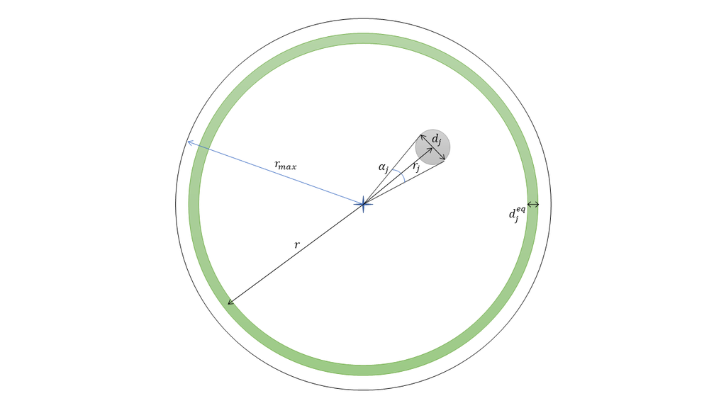

Figure 1.1: Diamètre équivalent du voisin $j$ pour $\alpha = 2 \pi$.

On peut définir (figure 1.1) un diamètre équivalent $d_j^{eq}$ pour le voisin $j$ correspondant à un angle apparent $\alpha$ arbitrairement choisi, ce qui permet de caractériser chaque voisin par cette seule valeur telle que

$${NCI}_i = \alpha \sum_j^{r_j \leq r_{max}}{d_j^{eq}}$$

où $d_j^{eq} = d_j \alpha_j / \alpha$.

Les diamètres équivalents des voisins s’additionnent pour définir un diamètre équivalent total des voisins de l’arbre $i$:

$${NCI}_i = \alpha d_i^{eq}.$$

## 1.3 Interprétation

En choisissant $\alpha = 2 \pi$, on voit que chaque voisin $j$ contribue à ${NCI}_i$ comme si son angle apparent était le cercle complet et que son diamètre était $d_j^{eq} = d_j^2 / (2 \pi r_j)$.

Pour un rayon $r$ quelconque autour de l’arbre $i$, choisi arbitrairement en respectant seulement $r \gg d_i^{eq}$, $2 \pi r d_i^{eq}$ est la surface de la couronne de largeur $d_i^{eq}$ centrée sur $r$ (la différence de périmètre entre l’intérieur et l’extérieur de la couronne est négligeable, et la couronne peut être assimilée à un rectangle de longueur $2 \pi r$ et de largeur $d_i^{eq}$).

L’indice d’encombrement divisé par $2 \pi$, c’est-à-dire ${NCI}_i / (2 \pi) = d_i^{eq}$, est donc la largeur d’une couronne qui encercle totalement l’arbre de référence $i$ à une distance $r$ arbitraire.

Sous l’hypothèse de la distribution complètement aléatoire des arbres, $d_i^{eq}$, comme ${NCI}_i$, est proportionnel à $r_{max}$. Dit autrement, les arbres les plus lointains contribuent moins mais sont plus nombreux: leur contribution totale est équivalente à celle des arbres les plus proches. La métrique la plus intéressante est donc

$${RCR}_i = d_i^{eq} / r_{max},$$
la proportion de l’espace (unidimensionnel) encombré par les voisins, noté ${RCR}_i$ pour *Radial Crowding Ratio*.

# 2 Application

## 2.1 Données

Parcelle 6 de Paracou:

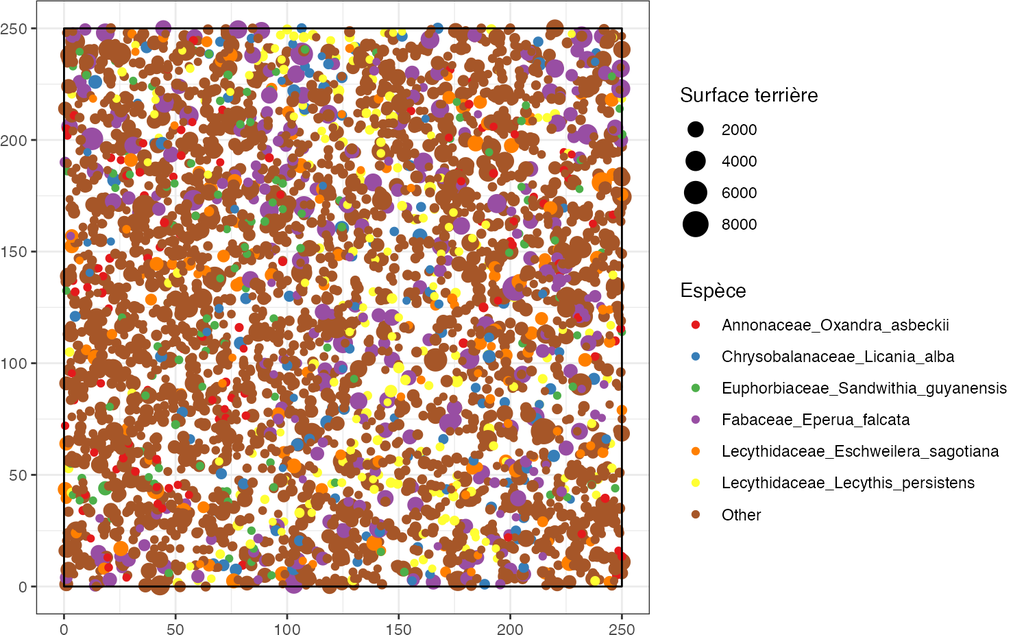

```r
load("data/Paracou6.rda")
library("dbmss")
autoplot(Paracou6) +
  ggplot2::labs(col = "Espèce", size = "Surface terrière")
```

## 2.2 Fonction de calcul de NCI

La fonction `NCI()` calcule l’indice d’encombrement neutre autour d’un arbre focal.

```r
library("spatstat.geom")

#' NCI
#'
#' Calculate NCI of point i
#'
#' @param i Index of a point of `ppp`.
#' @param ppp A planar point pattern.
#' @param distance_min The minimum distance of neighbors from the focal tree.
#' @param r_max The radius of the neighborhood
#' @param correct_edge_effects If `TRUE`, the Ripley correction of edge effects is applied,
#' else `NA` is returned for points too close to the edge of the window.
#'
#' @return The crowding index, in meters,
#' or `NA` if the point is too close to the edge of the window.
NCI <- function(i, ppp, distance_min = 0.25, r_max = 10, correct_edge_effects = TRUE) {
  # Neighborhood
  neighborhood <- ppp[disc(radius = r_max, centre = c(ppp$x[i], ppp$y[i]))]

  # Too close to the edge?
  is_too_close <- !is.subset.owin(neighborhood$window, ppp$window)
  if (is_too_close & !correct_edge_effects) {
    return(NA)
  }

  # Which is the center point?
  center_point <- which(neighborhood$x == ppp$x[i] & neighborhood$y == ppp$y[i])
  # Keep only one if several points have the same coordinates
  center_point <- center_point[1]
  # Distance from the center
  r_j <- pairdist(neighborhood)[, center_point]
  # Eliminate the center point
  r_j <- r_j[-center_point]
  # Set the minimum distance
  r_j <- pmax (r_j, distance_min)

  # Diameters
  d_j_squared <- neighborhood$marks$PointWeight * 4 / pi / 10000
  # Eliminate the center point
  d_j_squared <- d_j_squared[-center_point]
  # Normalized by distance.
  NCI_i_neutral <- d_j_squared / r_j

  # Edge effect correction
  if (is_too_close) {
    correction <- as.numeric(edge.Ripley(neighborhood[-center_point], r_j))
    NCI_i_neutral <- NCI_i_neutral * correction
  }

  return(sum(NCI_i_neutral))
}
```

```r
#' Relative Crowding Ratio
#'
#' @param ppp A planar point pattern.
#' @param distance_min The minimum distance of neighbors from the focal tree.
#' @param r_max The radius of the neighborhood
#' @param correct_edge_effects If `TRUE`, the Ripley correction of edge effects is applied,
#' else `NA` is returned for points too close to the edge of the window.
#'
#' @return A vector of relative crowding ratios of all points of `ppp`
#' that are far enough from the edge of the window.
RCR <- function(ppp, distance_min = 0.25, r_max = 10, correct_edge_effects = TRUE) {
  # Compute NCI. vapply returns a matrix. Trees are in columns.
  NCI_i <- vapply(
    seq_len(ppp$n),
    FUN = NCI,
    FUN.VALUE = 0,
    # Arguments
    ppp = ppp,
    distance_min = distance_min,
    r_max = r_max
  )
  # Eliminate points close to edges: neutral NCI is NA.
  NCI_i <- NCI_i[!is.na(NCI_i)]

  # Equivalent d
  d_i_eq <- NCI_i / 2 / pi

  # Crowding ratio
  return(d_i_eq / r_max)
}
```

## 2.3 Calcul des NCI de la parcelle 6

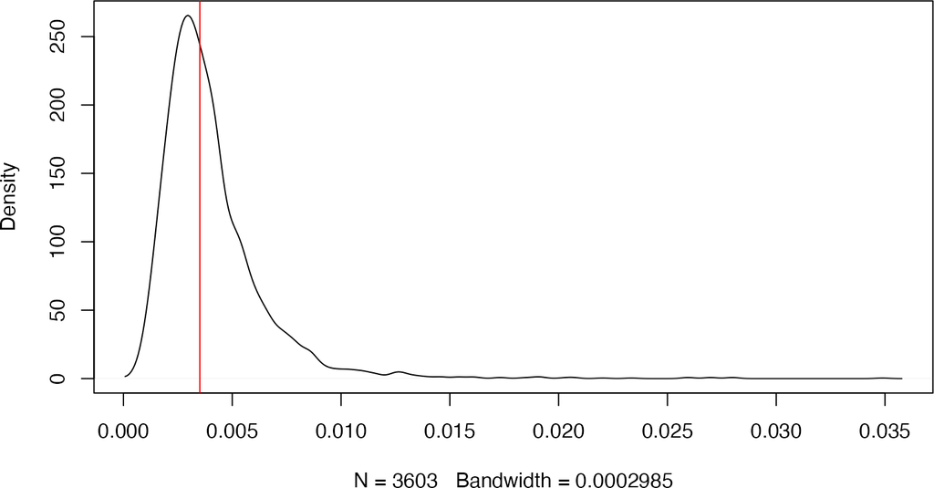

```r
# Compute crowding ratio
RCR_Paracou6 <- RCR(Paracou6)

# Distribution
RCR_median <- median(RCR_Paracou6)
library("GoFKernel")
plot(density.reflected(RCR_Paracou6, lower = 0), main = "")
abline(v = RCR_median, col = "red")
```

La valeur médiane du ratio d’encombrement est 3.5 pour mille.

## 2.4 Vérification de l’absence de sensibilité à la distance

En multipliant le rayon du voisinage par 2, NCI doit être approximativement multiplié par 2 et le ratio d’encombrement doit être stable. L’augmentation du rayon élimine des points proche de la bordure de la parcelle et lisse les données de voisinage. On s’attend à ce que la médiane soit stable et la variabilité plus faible.

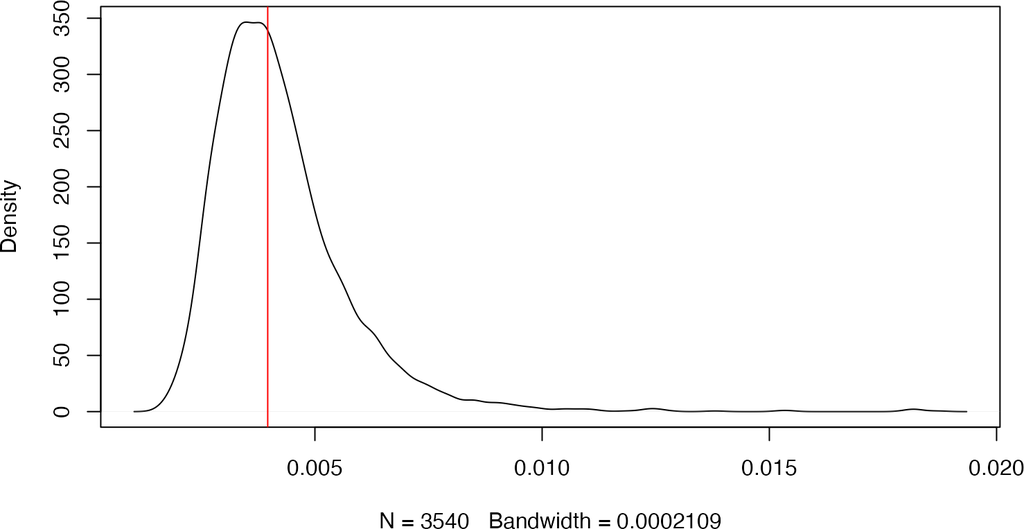

```r
# Compute crowding ratio
RCR_Paracou6_20 <- RCR(Paracou6, r_max = 20)

# Distribution
RCR_median_20 <- median(RCR_Paracou6_20)
plot(density.reflected(RCR_Paracou6_20, lower = 0), main = "")
abline(v = RCR_median_20, col = "red")
```

La valeur médiane du ratio d’encombrement est maintenant 4 pour mille.

## 2.5 Conclusion

Le RCR permet d’interpréter l’indice d’encombrement. C’est la largeur (normalisée par le rayon du voisinage) d’une couronne autour du point de référence dont le NCI est identique à la valeur observée. Sa valeur est faible : de l’ordre de 3 à 4 pour mille.

Sa définition est indépendante du rayon du voisinage. Sa valeur dans la parcelle 6 est très stable : à 60m (voisinage > 1ha), sa médiane est 4.3 pour mille. Le choix du rayon ne modifie donc pas l’encombrement moyen mais sa variabilité entre les arbres.

# 3 NCI non neutre

## 3.1 Définition

L’indice d’encombrement du voisinage de l’arbre $i$ est défini par

$${NCI}_i = \sum_j^{r_j \leq r_{max}}{\lambda_j d_j^2 / r_j}.$$

## 3.2 Interprétation géométrique

L’interprétation est similaire à celle du NCI neutre.

Pour chaque voisin, $d_j^{eq} = \lambda_j d_j \alpha_j / \alpha$. En choisissant $\alpha = 2 \pi$, chaque voisin $j$ contribue à ${NCI}_i$ comme si son angle apparent était le cercle complet et que son diamètre était $d_j^{eq} = \lambda_j d_j^2 / (2 \pi r_j)$.

La définition ${RCR}_i = d_i^{eq} / r_{max}$ ne change pas. De même que $NCI_i$ peut être négatif, $d_i^{eq}$ et ${RCR}_i$ peuvent être négatifs.